# EDAV Fall 2019 PSet 5, part A

Priyanka Lahoti, Hima Bindu Bhardwaj, Jasmine Bao, Yingnan Wu (Group 10)

This assignment is designed to help you get started on the final project. Be sure to review the final project instructions (https://edav.info/project.html), in particular the new section on reproducible workflow (https://edav.info/project.html#reproducible-workflow), which summarizes principles that we’ve discussed in class.

### 1. The Team

[2 points]

1. Who’s on the team? (Include names and UNIs)
- Priyanka Lahoti (UNI: pvl2111)
- Hima Bindu Bhardwaj (UNI: hb2635)
- Jasmine Bao (UNI: sb4320)
- Yingnan Wu (UNI: yw3431)
2. How do you plan to divide up the work? (Grading is on a group basis. The point of asking is to encourage you to think about this.)
- Priyanka Lahoti: Question a) and b)
- Hima Bindu Bhardwaj: Collecting datasets and Question c)
- Jasmine Bao: Collecting datasets and Question c)
- Yingnan Wu: Question a) and b)

### 2. The Questions

[6 points]

List three questions that you hope you will be able to answer from your research.

- General visualization explorations of wars, such as:
  - what types of wars happened most frequently,
  - which country initiated inter-state wars most frequently,
  - which war type caused the most number of deaths,
  - what wars caused the most number of deaths,
  - is the number of deaths correlated to whether the country is an initiator of an inter-state war or not,
  - is there a pattern between initiators and winners of inter-state wars,
  - what countries had most losses of human lives due to the war,
  - what countries participated most actively in the wars,
  - is there a pattern of the starting month of all wars, etc.
- What are the similarities and differences between World War I and World War II? (e.g., How were the global food prices affected during WW1 and WW2 time periods?)
- What are the effects of wars on the economics, food production, population, and education of some countries? (We may focus on some countries like Japan, Russia, Germany, China, United Kingdom, France that both participated in WWI and WWII.)

### 3. Which output format do you plan to use to submit the project?

[2 points]

(You don’t have to use the same format for this assignment – PSet 5, part A – and the final project itself.)

**html_document**

(Remember that it’s ok to have pieces of the project that don’t fit into the chosen output format; in those cases you can provide links to the relevant material.)

### 4. The Data

What is your data source? What is your method for importing data? Please be specific. Provide relevant information such as any obstacles you’re encountering and what you plan to do to overcome them.

[5 points]

Our data is from [The Correlates of War Project](http://www.correlatesofwar.org/), a project that seeks to facilitate the collection, dissemination, and use of accurate and reliable quantitative data in international relations. There are four data sets which are about extra-state wars, inter-state wars, intra-state wars, and non-state wars respectively. Each data set is available as a `csv` file and comes with a codebook that defines each variable clearly. Therefore, our method of importing data is simply downloading the datasets and importing into RStudio with `read.csv()` function.

In addition, we plan to merge other data sets about economics into our analysis, especially for the third question in Part 2 above. Our population and real GDP per capital data is from the [Maddison Project Database](https://www.rug.nl/ggdc/historicaldevelopment/maddison/releases/maddison-project-database-2018) which provides information on comparative economic growth and income levels over the very long run. Specifically, this dataset includes data on real GDP per capita in 2011 US dollars and population for the two world wars and is available in csv format.

### 5. Provide a short summary, including 2-3 graphs, of your initial investigations.

[10 points]

The dataset has 4 tables corresponding to inter-state wars, intra-state wars, non state wars and extra state wars.

```r
# import data
inter_state <- read.csv('Inter-StateWarData_v4.0.csv')
intra_state <- read.csv('Intra-StateWarData_v4.1.csv')
extra_state <- read.csv('Extra-StateWarData_v4.0.csv')
non_state <- read.csv('Non-StateWarData_v4.0.csv')
```

Intra state wars are further categorized into 3 types as follows:

```r
Civil_intra_state <- intra_state %>% filter(WarType==4 | WarType==5)
Regional_internal_intra_state <- intra_state %>% filter(WarType==6)
Intercommunal_intra_state <-intra_state %>% filter(WarType==7)
```

We first merged all four datasets to answer what types of wars happened most frequently. Based on *Figure 1*, we found that among all war types, there are most inter-state wars (Type 1), civil wars for central control (Type 4) and civil wars for local issues (Type 5), which are expected types that happened in history.

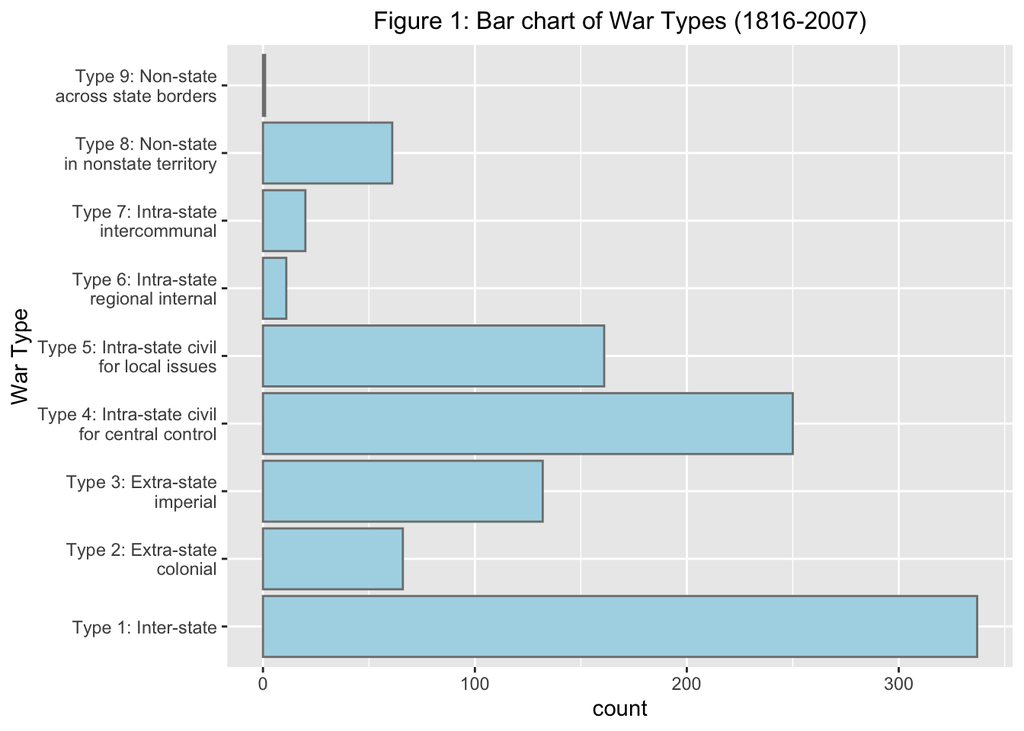

```r
intra <- intra_state %>% select(WarNum, WarName, WarType) %>% mutate(dataset="Intra-state")
inter <- inter_state %>% select(WarNum, WarName, WarType) %>% mutate(dataset="Inter-state")
extra <- extra_state %>% select(WarNum, WarName, WarType) %>% mutate(dataset="Extra-state")
non <- non_state %>% select(WarNum, WarName, WarType) %>% mutate(dataset="Non-state")
total <- rbind(intra, inter, extra, non)

ggplot(total, aes(as.factor(WarType))) +
  geom_bar(color = "grey50", fill = "lightblue") +
  coord_flip() +
  xlab("War Type") +
  ggtitle("Figure 1: Bar chart of War Types (1816-2007)") +
  theme(plot.title = element_text(hjust = 0.5, size=12)) +
  scale_x_discrete(labels=c("Type 1: Inter-state",
                            "Type 2: Extra-state\ncolonial",
                            "Type 3: Extra-state\nimperial",
                            "Type 4: Intra-state civil\nfor central control",
                            "Type 5: Intra-state civil\nfor local issues",
                            "Type 6: Intra-state\nregional internal",
                            "Type 7: Intra-state\nintercommunal",
                            "Type 8: Non-state\nin nonstate territory",
                            "Type 9: Non-state\nacross state borders"))
```

Many wars transformed to other wars that took place later on. We found that 12 civil intra state wars transformed to inter state wars, 3 inter state wars transformed to extra state wars and 2 intra state wars transformed to extra state wars. We were able to find these transformed wars and store them as shown below:

```r
# 12 Civil_inta_state wars transformed to inter_state wars
intra_to_inter_wars=vector('numeric',length=0)
for (val in unique(Civil_intra_state%>%select(TransTo)%>%filter(TransTo!=-8))$TransTo ) {
  if(val %in%  unique(inter_state$WarNum)) {
    intra_to_inter_wars=append(intra_to_inter_wars, val, after = length(intra_to_inter_wars))
  }
}

# 3 inter_state wars transformed to extra_state wars
inter_to_extra_wars=vector('numeric',length=0)
for (val in unique(inter_state%>%select(TransTo)%>%filter(TransTo!=-8))$TransTo) {
  if(val %in% unique(extra_state$WarNum)) {
    inter_to_extra_wars=append(inter_to_extra_wars, val, after = length(inter_to_extra_wars))
  }
}

# 2 intra_state wars transformed to extra_state wars
intra_to_extra_wars=vector('numeric',length=0)
for (val in unique(Civil_intra_state%>%select(TransTo)%>%filter(TransTo!=-8))$TransTo) {
  if(val %in% unique(extra_state$WarNum)) {
    intra_to_extra_wars=append(intra_to_extra_wars, val, after = length(intra_to_extra_wars))
  }
}
```

Below is a world map plot of the number of battle deaths in thousands seen during inter state wars from 1816-2007. The color scheme highlights the magnitude of deaths with ease of comparison.

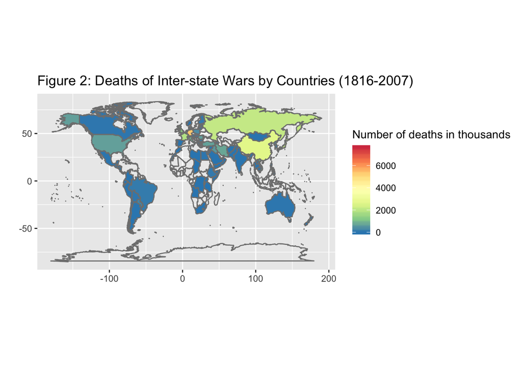

```r
df1=inter_state%>%group_by(StateName)%>%summarise(total_deaths=sum(BatDeath))

world <- map_data("world")

df1 <- df1 %>%
  ## Recode certain entries
  mutate(StateName = recode(str_trim(StateName),
                            "United States of America" = "USA",
                            "United Kingdom" = "UK",
                            "China (PRC)"="China",
                            "Taiwan (ROC)"="Taiwan",
                            "Yemen Arab Republic"="Yemen"))

df1$total_deaths=df1$total_deaths/1000

ggplot(df1, aes(map_id = StateName)) +
  geom_map(aes(fill = total_deaths), map = world) +
  expand_limits(x = world$long, y = world$lat) +
  borders(database = "world",
          regions = ".",
          fill = NA,
          colour = "grey50",
          xlim = NULL,
          ylim = NULL) +
  scale_fill_distiller(type = "seq",
                       palette = "Spectral",
                       direction = -1,
                       limits = c(min(df1$total_deaths), max(df1$total_deaths)),
                       na.value = "white",
                       name = "Number of deaths in thousands") +
  coord_fixed(1.3) +
  labs(title = "Figure 2: Deaths of Inter-state Wars by Countries (1816-2007)", x=" ", y=" ")
```

We then explored inter state wars and focused on the World War I and World War II specifically.

#### World War 1

On plotting a bar graph of the countries that were involved in the whole period of world war 1 (1914 -1918), we attempted to see which countries had maximum number of battle deaths. Following is the bar graph that plots the number of deaths corresponding to each country that was involved in World War 1.

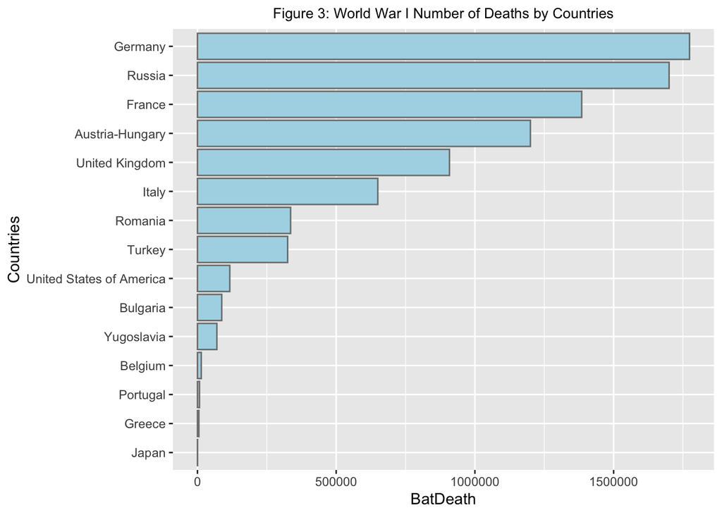

```r
#world_war1:: Years: 1914-1918
world_war1=inter_state%>%filter(WarName=='World War I')
world_war1$StateName=as.character(world_war1$StateName)

ggplot(world_war1, aes(x=reorder(StateName,BatDeath),y=BatDeath)) +
  geom_bar(color = "grey50", fill = "lightblue",stat='identity') +
  coord_flip()+
  xlab("Countries") +
  ggtitle("Figure 3: World War I Number of Deaths by Countries")+
  theme(plot.title = element_text(hjust = 0.5, size=10))
```

Below is a plot of the number of deaths of various countries during World War I:

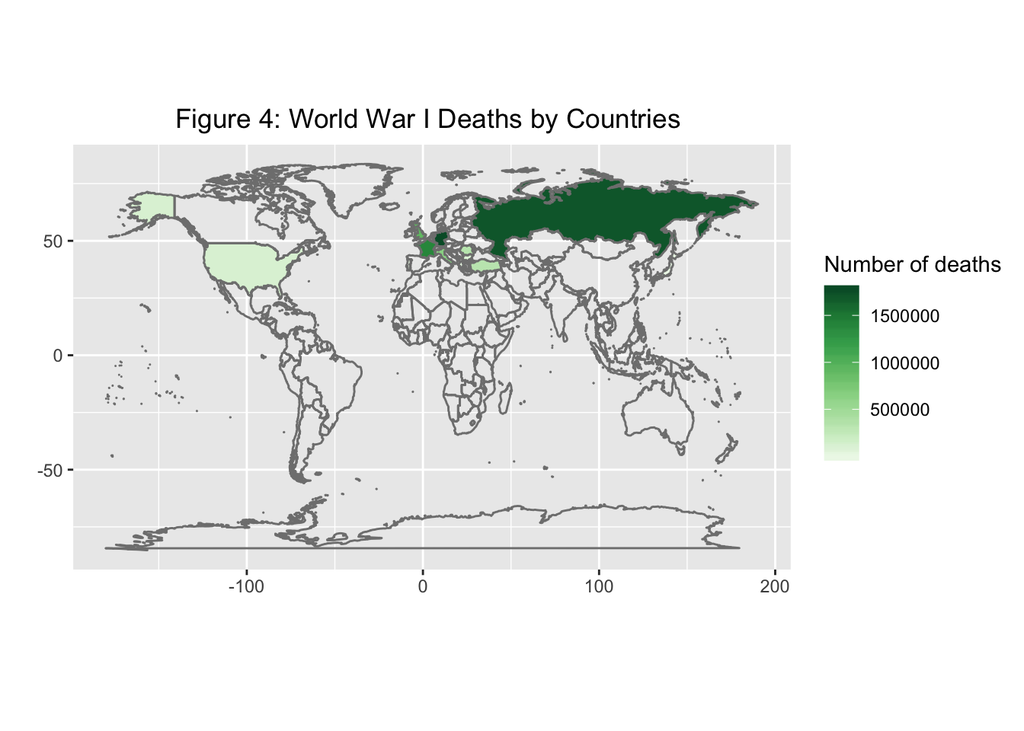

```r
#maps
world <- map_data("world")
world_war1 <- world_war1 %>%
  ## Recode certain entries
  mutate(StateName = recode(str_trim(StateName),
                            "United States of America" = "USA",
                            "United Kingdom" = "UK"))

world_war1['start_date'] <- as.Date(with(world_war1, paste(StartYear1, StartMonth1, StartDay1,sep="-")), "%Y-%m-%d")
world_war1['end_date'] <- as.Date(with(world_war1, paste(EndYear1, EndMonth1, EndDay1,sep="-")), "%Y-%m-%d")
world_war1['number_of_days']=world_war1['end_date']-world_war1['start_date']

ggplot(world_war1, aes(map_id = StateName)) +
  geom_map(aes(fill = BatDeath), map = world) +
  expand_limits(x = world$long, y = world$lat) +
  borders(database = "world",
          regions = ".",
          fill = NA,
          colour = "grey50",
          xlim = NULL,
          ylim = NULL)+
  scale_fill_distiller(type = "seq",
                       palette = "Greens",
                       direction = 1,
                       na.value = "white",
                       name = "Number of deaths") +
  coord_fixed(1.3) +
  labs(title = "Figure 4: World War I Deaths by Countries " ,x=" ",y=" ") +
  theme(plot.title = element_text(hjust = 0.5))
```

Below is a plot of the number of days that various countries fought during World War I:

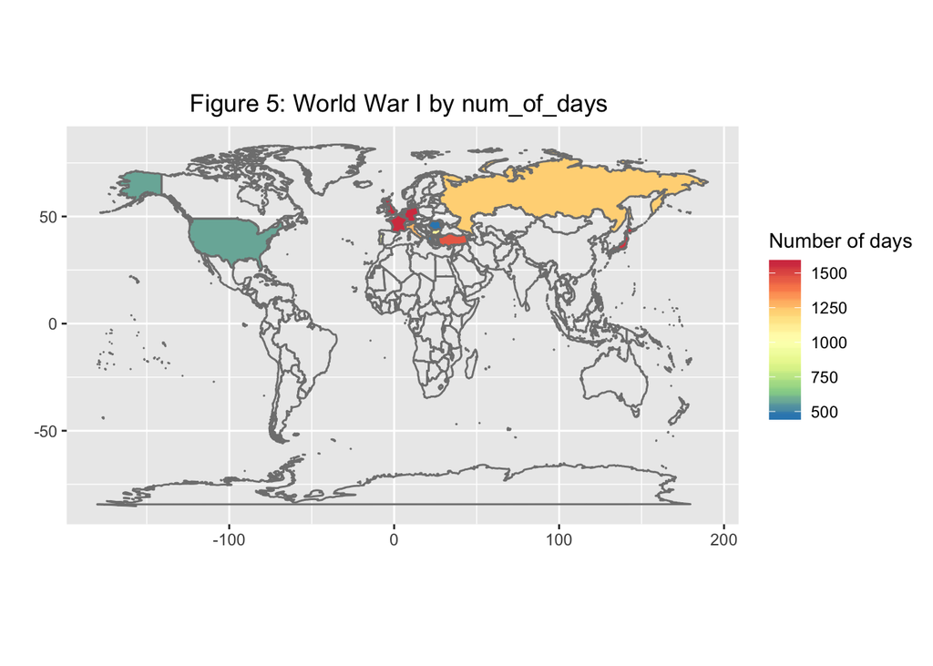

```r
world_war1$number_of_days <- as.numeric(world_war1$number_of_days )

ggplot(world_war1, aes(map_id = StateName)) +
  geom_map(aes(fill = number_of_days), map = world) +
  expand_limits(x = world$long, y = world$lat) +
  borders(database = "world", regions = ".", fill = NA, colour = "grey50", xlim = NULL, ylim = NULL)+
  scale_fill_distiller(type = "seq",
                       palette = "Spectral",
                       direction = -1,
                       na.value = "white",
                       name = "Number of days") +
  coord_fixed(1.3) +
  labs(title = "Figure 5: World War I by num_of_days " ,x=" ",y=" ") +
  theme(plot.title = element_text(hjust = 0.5))
```

We tried to investigate whether there was some correlation between the number of days a country fought and the number of deaths for both sides of the war. There was no correlation between number of deaths and number of days spent on battlefield. There were instances where number of days in battle was high but number of deaths was low and vice versa for both sides. So, there may be other factors that lead to more (or less) number of deaths (military equipment or training, advancement in technology, etc) which we intend to further investigate. Below is the interactive parallel coordinate plot.

```r
ww1 <- subset(world_war1, select = c(5,24, 28,6))
ww1$BatDeath=as.numeric(ww1$BatDeath)
ww1$number_of_days=as.numeric(ww1$number_of_days)
ww1$Side <- as.character(ww1$Side)
# ww1$Side <- as.factor(ww1$Side)
ww1$Side[ww1$Side == "1"] <- "A"
ww1$Side[ww1$Side == "2"] <- "B"

# theme_set(theme_grey(14))

parcoords(ww1 ,brushMode = '1D-axes', reorderable = TRUE, withD3 = TRUE,
          color = list(
            colorScale = "scaleOrdinal",
            colorBy = "Side",
            colorSheme = "schemeCategory10"),
          rownames = FALSE)
```

[interactive chart not shown]

#### World War 2

Below is a bar graph of the number of deaths of various countries during World War 2:

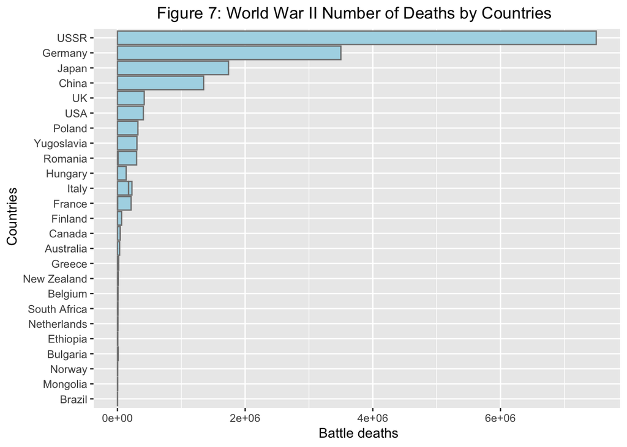

```r
#world_war2:: Years: 1939-1945
world_war2=inter_state%>%filter(WarName=='World War II')
world_war2$StateName=as.character(world_war2$StateName)
#maps
world <- map_data("world")
world_war2 <- world_war2 %>%
  ## Recode certain entries
  mutate(StateName = recode(str_trim(StateName),
                            "United States of America" = "USA",
                            "United Kingdom" = "UK"))

ggplot(world_war2, aes(x=reorder(StateName,BatDeath), y=BatDeath)) +
  geom_bar(color = "grey50", fill = "lightblue", stat='identity') +
  coord_flip()+
  labs(title = "Figure 7: World War II Number of Deaths by Countries " ,x=" Countries",y=" Battle deaths") +
  theme(plot.title = element_text(hjust = 0.5))
```

Below is a plot of the number of deaths of various countries during World War 2:

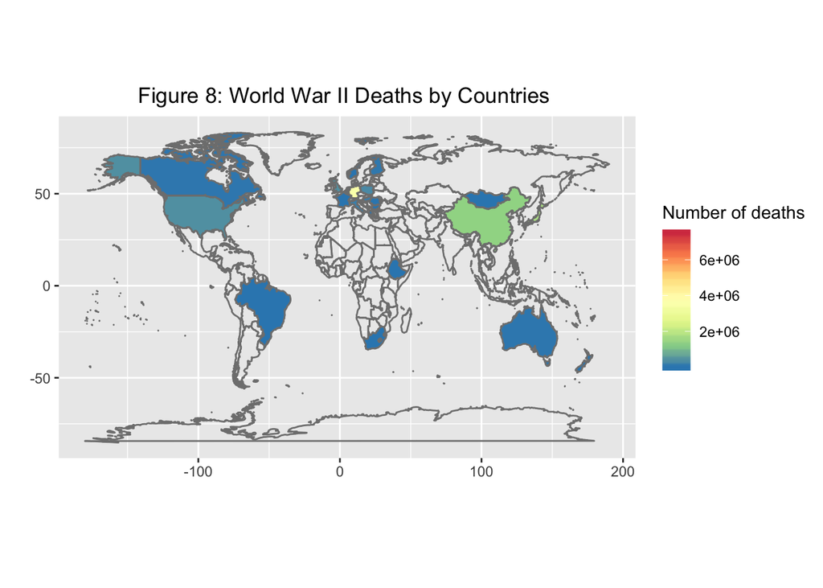

```r
ggplot(world_war2, aes(map_id = StateName)) +
  geom_map(aes(fill = BatDeath), map = world) +
  expand_limits(x = world$long, y = world$lat) +
  borders(database = "world", regions = ".", fill = NA,
          colour = "grey50", xlim = NULL, ylim = NULL)+
  scale_fill_distiller(type = "seq",
                       palette = "Spectral",
                       direction = -1,
                       na.value = "white",
                       name = "Number of deaths") +
  coord_fixed(1.3) +
  labs(title = "Figure 8: World War II Deaths by Countries ", x=" ", y=" ") +
  theme(plot.title = element_text(hjust = 0.5))
```